# Create Inverse Function

Wed Aug 27

# An inverse function UNDOES operations in REVERSE order

To put on footwear:

1. Put on socks.
2. Put on shoes.
3. Tie shoes.

To invert…

1. Untie shoes
2. Remove shoes
3. Remove socks

# PEMDAS: order of operations

Review, evaluate the expression:

$$10-2\cdot 3$$

- The multiplication occurs before the subtraction.
- $10-6~=~ 4$

# Many functions are a sequence of operations.

Consider the function shown below:

$$f(x)~=~\frac{2x-7}{5}$$

What are the operations applied to the input?

1. Multiply by 2.
2. Subtract 7.
3. Divide by 5.
- How would you undo those operations in reverse order?
1. Multiply by 5.
2. Add 7.
3. Divide by 2.
- Indeed, $f^{-1}(x)~=~\frac{5x+7}{2}$

# A function and its inverse undo each other

Consider the algebraic definitions of a function and its inverse:

$$f(x)~=~\frac{2x-7}{5}$$

$$f^{-1}(x)~=~\frac{5x+7}{2}$$

Evaluate $f(11)$

# A function and its inverse undo each other

Consider the algebraic definitions of a function and its inverse:

$$f(x)~=~\frac{2x-7}{5}$$

$$f^{-1}(x)~=~\frac{5x+7}{2}$$

Evaluate $f(11)$

$$f(11)~=~\frac{2(11)-7}{5}$$

$$f(11)~=~\frac{22-7}{5}$$

$$f(11)~=~\frac{15}{5}$$

$$f(11)~=~3$$

# A function and its inverse undo each other

Consider the algebraic definitions of a function and its inverse:

$$f(x)~=~\frac{2x-7}{5}$$

$$f^{-1}(x)~=~\frac{5x+7}{2}$$

Evaluate $f^{-1}(3)$

# A function and its inverse undo each other

Consider the algebraic definitions of a function and its inverse:

$$f(x)~=~\frac{2x-7}{5}$$

$$f^{-1}(x)~=~\frac{5x+7}{2}$$

Evaluate $f^{-1}(3)$

$$f^{-1}(3)~=~\frac{5(3)+7}{2}$$

$$f^{-1}(3)~=~\frac{15+7}{2}$$

$$f^{-1}(3)~=~\frac{22}{2}$$

$$f^{-1}(3)~=~11$$

# A function and its inverse undo each other

Consider the algebraic definitions of a function and its inverse:

$$f(x)~=~\frac{2x-7}{5}$$

$$f^{-1}(x)~=~\frac{5x+7}{2}$$

Notice $f(11)=3$ and $f^{-1}(3)=11$.

# To get an inverse function, “swap $x$ and $y$”

A one-to-one function, $g$, is defined with the table below.

| $x$ | $g(x)$ |
| --- | --- |
| 1 | 3 |
| 2 | 6 |
| 3 | 2 |
| 4 | 4 |
| 5 | 5 |
| 6 | 1 |

Can you identify the values to put in the inverse function’s table?

| $x$ | $g^{-1}(x)$ |
| --- | --- |
| 1 |  |
| 2 |  |
| 3 |  |
| 4 |  |
| 5 |  |
| 6 |  |

# To get an inverse function, “swap $x$ and $y$”

A one-to-one function, $g$, is defined with the table below.

| $x$ | $g(x)$ |
| --- | --- |
| 1 | 3 |
| 2 | 6 |
| 3 | 2 |
| 4 | 4 |
| 5 | 5 |
| 6 | 1 |

Can you identify the values to put in the inverse function’s table?

| $x$ | $g^{-1}(x)$ |
| --- | --- |
| 1 | 6 |
| 2 |  |
| 3 |  |
| 4 |  |
| 5 |  |
| 6 |  |

# To get an inverse function, “swap $x$ and $y$”

A one-to-one function, $g$, is defined with the table below.

| $x$ | $g(x)$ |
| --- | --- |
| 1 | 3 |
| 2 | 6 |
| 3 | 2 |
| 4 | 4 |
| 5 | 5 |
| 6 | 1 |

Can you identify the values to put in the inverse function’s table?

| $x$ | $g^{-1}(x)$ |
| --- | --- |
| 1 | 6 |
| 2 | 3 |
| 3 |  |
| 4 |  |
| 5 |  |
| 6 |  |

# To get an inverse function, “swap $x$ and $y$”

A one-to-one function, $g$, is defined with the table below.

| $x$ | $g(x)$ |
| --- | --- |
| 1 | 3 |
| 2 | 6 |
| 3 | 2 |
| 4 | 4 |
| 5 | 5 |
| 6 | 1 |

Can you identify the values to put in the inverse function’s table?

| $x$ | $g^{-1}(x)$ |
| --- | --- |
| 1 | 6 |
| 2 | 3 |
| 3 | 1 |
| 4 |  |
| 5 |  |
| 6 |  |

# To get an inverse function, “swap $x$ and $y$”

A one-to-one function, $g$, is defined with the table below.

| $x$ | $g(x)$ |
| --- | --- |
| 1 | 3 |
| 2 | 6 |
| 3 | 2 |
| 4 | 4 |
| 5 | 5 |
| 6 | 1 |

Can you identify the values to put in the inverse function’s table?

| $x$ | $g^{-1}(x)$ |
| --- | --- |
| 1 | 6 |
| 2 | 3 |
| 3 | 1 |
| 4 | 4 |
| 5 |  |
| 6 |  |

# To get an inverse function, “swap $x$ and $y$”

A one-to-one function, $g$, is defined with the table below.

| $x$ | $g(x)$ |
| --- | --- |
| 1 | 3 |
| 2 | 6 |
| 3 | 2 |
| 4 | 4 |
| 5 | 5 |
| 6 | 1 |

Can you identify the values to put in the inverse function’s table?

| $x$ | $g^{-1}(x)$ |
| --- | --- |
| 1 | 6 |
| 2 | 3 |
| 3 | 1 |
| 4 | 4 |
| 5 | 5 |
| 6 |  |

# To get an inverse function, “swap $x$ and $y$”

A one-to-one function, $g$, is defined with the table below.

| $x$ | $g(x)$ |
| --- | --- |
| 1 | 3 |
| 2 | 6 |
| 3 | 2 |
| 4 | 4 |
| 5 | 5 |
| 6 | 1 |

Can you identify the values to put in the inverse function’s table?

| $x$ | $g^{-1}(x)$ |
| --- | --- |
| 1 | 6 |
| 2 | 3 |
| 3 | 1 |
| 4 | 4 |
| 5 | 5 |
| 6 | 2 |

# Graphically, a function and its inverse have reflective symmetry over the $y=x$ line.

The [one-to-one](https://en.wikipedia.org/wiki/Injective_function) function $f$ is plotted below:

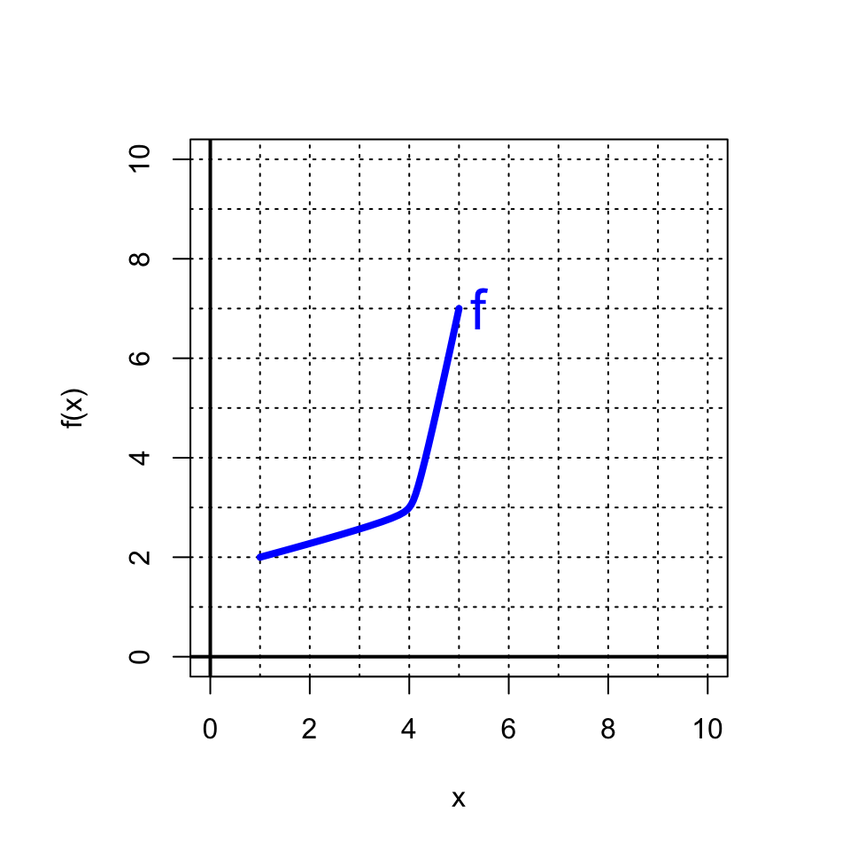

Can you draw the inverse function?

# Graphically, a function and its inverse have reflective symmetry over the $y=x$ line.

The [one-to-one](https://en.wikipedia.org/wiki/Injective_function) function $f$ is plotted below:

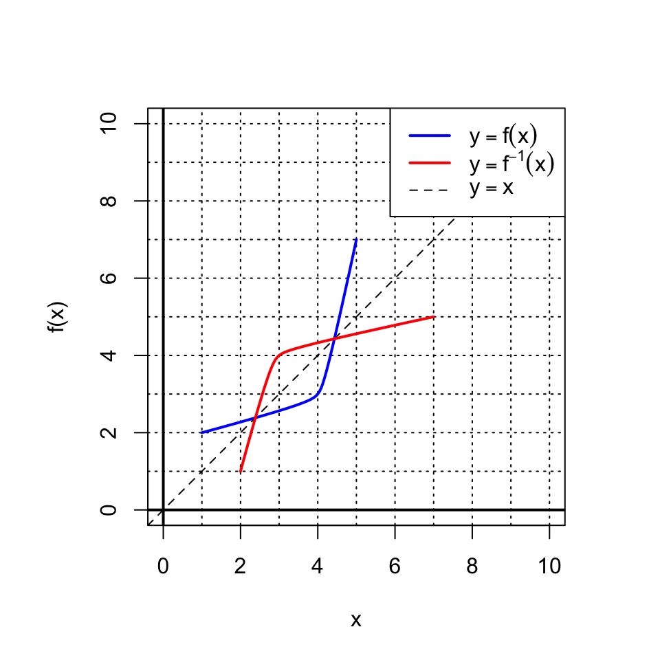